# Homework 2

Lacey Gleason

2/21/2018

### Installing the `car` package

- install.packages(“quantreg”, dependencies=TRUE)
- install.packages(“car”, dependencies=TRUE)

### The Data - `Davis` dataset in the `car` package

The `Davis` dataset in the `car` package contains data on the measured and reported heights and weights of men and women engagedin regular exercise.

```r
library(dplyr)
library(car)
dataDavis <- car::Davis
```

Use tools within the `dplyr` package as much as possible to answer the following questions.

### **Question 1:** What kind of R object is the `Davis` dataset?

```r
class(dataDavis)
```

```
## [1] "data.frame"
```

```r
str(dataDavis)
```

```
## 'data.frame':    200 obs. of  5 variables:
##  $ sex   : Factor w/ 2 levels "F","M": 2 1 1 2 1 2 2 2 2 2 ...
##  $ weight: int  77 58 53 68 59 76 76 69 71 65 ...
##  $ height: int  182 161 161 177 157 170 167 186 178 171 ...
##  $ repwt : int  77 51 54 70 59 76 77 73 71 64 ...
##  $ repht : int  180 159 158 175 155 165 165 180 175 170 ...
```

The `Davis` dataset is a data.frame with 200 observations and 5 variables. The variables in the `Davis` dataset are sex, measured weight in kg, measured height in cm, reported weight in kg, and reported height in cm.

### **Question 2:** How many observations are in the `Davis` dataset?

```r
dataDavis %>%
  summarise(nObs = n())
```

```
##   nObs
## 1  200
```

There are two hundred observations in the `Davis` dataset.

### **Question 3:** For reported weight, how many observations have a missing value?

```r
missingWeight <- is.na(dataDavis$repwt)
sum(missingWeight)
```

```
## [1] 17
```

```r
mean(missingWeight)
```

```
## [1] 0.085
```

For reported weight, 17 observations (8.5%) have a missing value.

### **Question 4:** How many observations have no missing values? *(HINT: find complete cases)*

```r
completeObs <- complete.cases(dataDavis)
table(completeObs)
```

```
## completeObs
## FALSE  TRUE
##    19   181
```

One hundred and eighty-one observations have no missing values.

Create a subset containing only females.

```r
dataFemale <- dataDavis %>%
  filter(sex == "F")
```

### **Question 5:** How many females are in this subset?

```r
dataFemale %>%
  summarise(nObs = n())
```

```
##   nObs
## 1  112
```

There are 112 females in the subset containing only females.

*Now* return to the overall dataset with both males and females.

Body mass index is one way to quantify the amount of tissue mass (muscle, fat, and bone) in an individual, then categorize that person as *underweight*, *normal* *weight*, *overweight*, or *obese* according to that value.

We calculate the BMI as the **ratio of the weight in kilograms divided by the square of the height in meters**, and the categorization based on BMI is as follows:

#### BMI Categories

| Category | BMI range (kg/m2) |
| --- | --- |
| Underweight | <18.5 |
| Normal | 18.5 to <25 |
| Overweight | 25 to <30 |
| Obese | 30 or higher |

Create the BMI variable and then a variable to depict BMI category. Note that the `height` variable is in centimeters, and `weight` is in kg. You need to create the BMI variable using the correct formula.

```r
dataDavis <- dataDavis %>%
  mutate(BMI = (weight/((height/100)^2)))
```

```r
dataDavis <- dataDavis %>%
  mutate(BMIcat = if_else(BMI<18.5, "Underweight",
                     if_else(BMI<25, "Normal",
                        if_else(BMI<30, "Overweight",
                          "Obese", "Missing"),"Missing"),"Missing"))
```

Now answer these questions:

### **Question 6:** What is the average BMI for these individuals?

```r
dataDavis %>%
  summarise(meanBMI = mean(BMI),
            sdBMI = sd(BMI))
```

```
##    meanBMI    sdBMI
## 1 24.70096 34.68423
```

The mean BMI is 24.7 kilograms per meter squared.

### **Question 7:** How do these individuals fall into the BMI categories (what are the frequencies and relative %’s)?

```r
dataDavis %>%
  count(BMIcat)
```

```
## # A tibble: 4 x 2
##   BMIcat          n
##   <chr>       <int>
## 1 Normal        143
## 2 Obese           4
## 3 Overweight     35
## 4 Underweight    18
```

```r
library(janitor)
library(knitr)
dataDavis %>%
  janitor::tabyl(BMIcat) %>%
  knitr::kable()
```

| BMIcat | n | percent |
| --- | --- | --- |
| Normal | 143 | 0.715 |
| Obese | 4 | 0.020 |
| Overweight | 35 | 0.175 |
| Underweight | 18 | 0.090 |

There are 18 (9.0%) individuals in the underweight category. There are 143 (71.5%) individuals in the normal category. There are 35 (17.5%) individuals in the overweight category. There are four (2.0%) individuals in the obese category.

## Test your graphing skills using `ggplot2`

Using the `Davis` dataset from the `car` package, create the following graphics/figures using `ggplot()` and associated `geom_xxx()` functions.

### **Question 8:** Create a histogram of BMI.

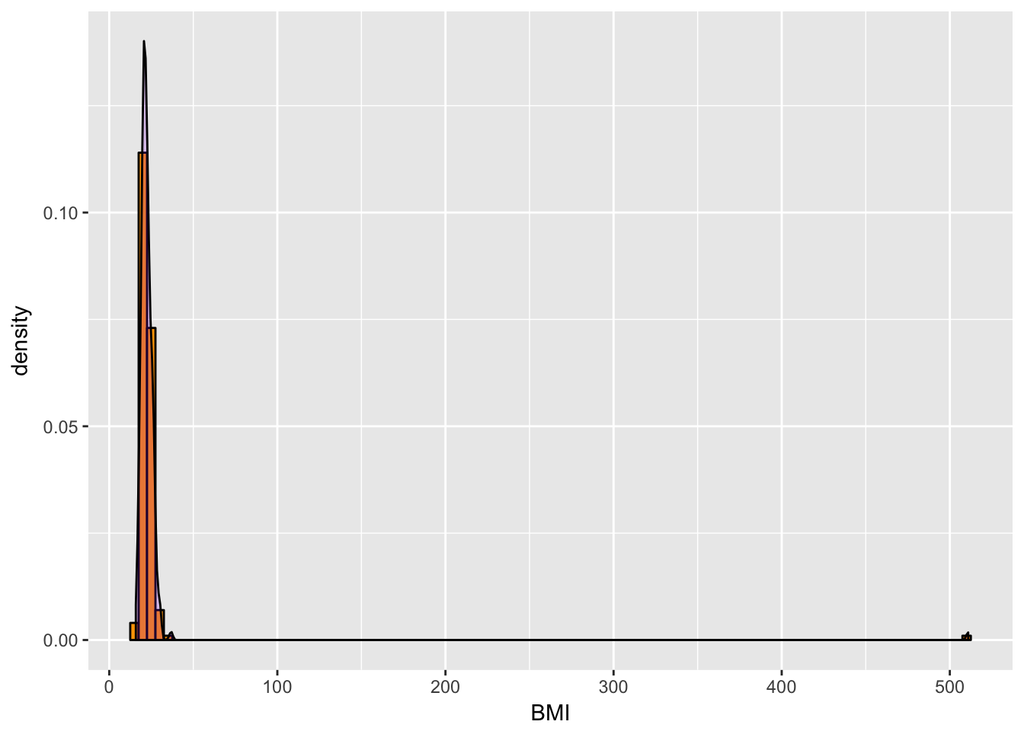

```r
library(ggplot2)

  ggplot(dataDavis, aes(x=BMI)) +
    geom_histogram(aes(y=..density..),
                   binwidth=5,
                   colour="black", fill="orange") +
    geom_density(alpha=.2, fill="purple")
```

*What do you notice about the distribution (any outliers or skewness)?*  
Yes, there is a very high outlier that is above 500.

```r
# Remove high outlier in BMI - it would not be possible to have this value
dataNoOut<-dataDavis[!(dataDavis$BMI>204),]
```

### **Question 9:** Create side-by-side boxplots of the BMI distributions by gender

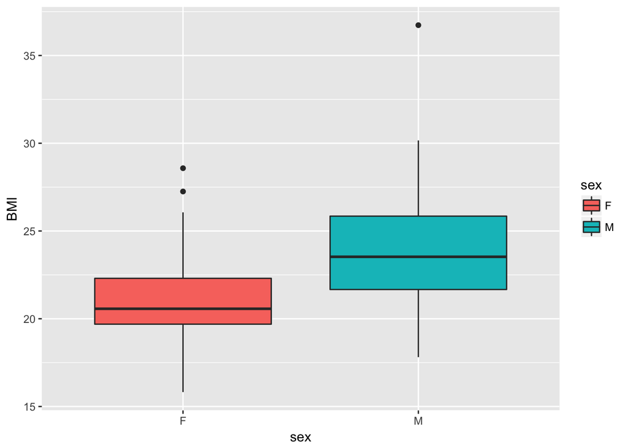

```r
# A basic box with the conditions colored
ggplot(dataNoOut,
       aes(x=sex, y=BMI, fill=sex)) +
  geom_boxplot()
```

### **Question 10:** Create a clustered bar chart of the BMI categories by gender

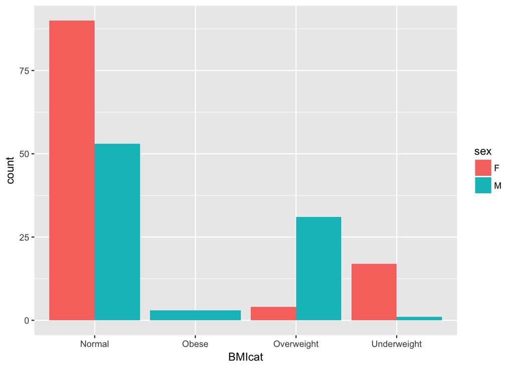

```r
# cluster barchart of BMI categories by gender
dataNoOut %>% ggplot(aes(x=BMIcat, fill=sex)) +
  geom_bar(position = "dodge")
```

*(note: the y-axis should be counts)*

## Link for assignment on Github

https://github.com/lpgleason/N741Homework2.git